# Example using methylseqextractor

This document illustrates how to use all functionality of ‘methylseqextractor’ https://github.com/perishky/methylseqextractor.

## Import methylseqextractor modules

All necessary modules can be imported as follows:

```python
from methylseqextractor import (
  Window,
  MethylSeqDataset,
  LevelCalculator,
  ClonalFlipCounter,
  ConcurrenceCalculator,
  CAMDACalculator
)
```

In the examples below, we’ll use `pandas` to store outputs as data frames.

```python
import pandas as pd
```

## Extract reads containing specified CpG sites

We can extract the reads overlapping each of a selected set of CpG sites.

Here we prepare to extract reads overlapping CpG sites in the region chr1:1245000-1246000.

```python
bamfn = "data/sample.bam"
fastafn = "genome/hg19.fa"
dataset = MethylSeqDataset(bamfn, fastafn)
iter = dataset.methylation("chr1",1245000,1246000)
```

Each step of this iterator will return the reads of a different CpG site. Here are the reads for the first CpG site.

```python
site = next(iter)
pd.DataFrame([cread.to_dict() for cread in site.get_creads()])
```

|  | read | chrom | pos | strand | base | is_methylated |
| --- | --- | --- | --- | --- | --- | --- |
| 0 | M04360:9:000000000-LH9RH:1:2103:12934:17955-ch... | chr1 | 1245002 | + | C | True |
| 1 | M04360:9:000000000-LH9RH:1:2109:6257:10400-chr... | chr1 | 1245002 | + | T | False |
| 2 | M04360:9:000000000-LH9RH:1:1108:22978:8011-chr... | chr1 | 1245002 | + | T | False |
| 3 | M04360:9:000000000-LH9RH:1:1101:14153:6435-chr... | chr1 | 1245002 | + | C | True |
| 4 | M04360:9:000000000-LH9RH:1:1109:21086:9700-chr... | chr1 | 1245002 | - | G | True |

And the second CpG site.

```python
site = next(iter)
pd.DataFrame([cread.to_dict() for cread in site.get_creads()])
```

|  | read | chrom | pos | strand | base | is_methylated |
| --- | --- | --- | --- | --- | --- | --- |
| 0 | M04360:9:000000000-LH9RH:1:2103:12934:17955-ch... | chr1 | 1245013 | + | C | True |
| 1 | M04360:9:000000000-LH9RH:1:2109:6257:10400-chr... | chr1 | 1245013 | + | C | True |
| 2 | M04360:9:000000000-LH9RH:1:1108:22978:8011-chr... | chr1 | 1245013 | + | C | True |
| 3 | M04360:9:000000000-LH9RH:1:1101:14153:6435-chr... | chr1 | 1245013 | + | C | True |
| 4 | M04360:9:000000000-LH9RH:1:1109:21086:9700-chr... | chr1 | 1245013 | - | A | False |

## Calculate DNA methylation levels

A variety of summary statistics can be calculated from these read sets.

One is the proportion of reads in which a CpG site is methylated

Here we calculate DNA methylation levels for each CpG site in the region chr1:1245000-1246000.

```python
levels = LevelCalculator(dataset,min_depth=10)
iter = levels.calculate("chr1", 1245000, 1246000)
pd.DataFrame([site for site in iter])
```

|  | chrom | pos | strand | nmeth | nunmeth | meth_pct |
| --- | --- | --- | --- | --- | --- | --- |
| 0 | chr1 | 1245090 | * | 9 | 1 | 0.900000 |
| 1 | chr1 | 1245105 | * | 10 | 3 | 0.769231 |
| 2 | chr1 | 1245114 | * | 10 | 3 | 0.769231 |
| 3 | chr1 | 1245123 | * | 14 | 0 | 1.000000 |
| 4 | chr1 | 1245135 | * | 14 | 1 | 0.933333 |
| 5 | chr1 | 1245146 | * | 18 | 1 | 0.947368 |
| 6 | chr1 | 1245152 | * | 16 | 4 | 0.800000 |
| 7 | chr1 | 1245159 | * | 17 | 5 | 0.772727 |
| 8 | chr1 | 1245163 | * | 19 | 3 | 0.863636 |
| 9 | chr1 | 1245167 | * | 22 | 2 | 0.916667 |
| 10 | chr1 | 1245172 | * | 24 | 2 | 0.923077 |
| 11 | chr1 | 1245175 | * | 23 | 4 | 0.851852 |
| 12 | chr1 | 1245183 | * | 27 | 2 | 0.931034 |
| 13 | chr1 | 1245219 | * | 28 | 4 | 0.875000 |
| 14 | chr1 | 1245272 | * | 22 | 4 | 0.846154 |
| 15 | chr1 | 1245322 | * | 19 | 1 | 0.950000 |
| 16 | chr1 | 1245337 | * | 17 | 1 | 0.944444 |
| 17 | chr1 | 1245373 | * | 12 | 0 | 1.000000 |
| 18 | chr1 | 1245377 | * | 11 | 0 | 1.000000 |

CpG sequences are symmetric on DNA strands. By default, `MethylSeqDataset` merges these as if they are a single genomic position. It is possible to prevent merging.

```python
dataset_stranded = MethylSeqDataset(bamfn, fastafn, merge_strands=False)
levels = LevelCalculator(dataset_stranded,min_depth=5)
iter = levels.calculate("chr1", 1245000, 1246000)
pd.DataFrame([site for site in iter])
```

|  | chrom | pos | strand | nmeth | nunmeth | meth_pct |
| --- | --- | --- | --- | --- | --- | --- |
| 0 | chr1 | 1245075 | + | 1 | 4 | 0.200000 |
| 1 | chr1 | 1245090 | + | 6 | 0 | 1.000000 |
| 2 | chr1 | 1245105 | + | 5 | 2 | 0.714286 |
| 3 | chr1 | 1245106 | - | 5 | 1 | 0.833333 |
| 4 | chr1 | 1245114 | + | 5 | 2 | 0.714286 |
| 5 | chr1 | 1245115 | - | 5 | 1 | 0.833333 |
| 6 | chr1 | 1245123 | + | 8 | 0 | 1.000000 |
| 7 | chr1 | 1245124 | - | 6 | 0 | 1.000000 |
| 8 | chr1 | 1245135 | + | 8 | 1 | 0.888889 |
| 9 | chr1 | 1245136 | - | 6 | 0 | 1.000000 |
| 10 | chr1 | 1245146 | + | 12 | 1 | 0.923077 |
| 11 | chr1 | 1245147 | - | 6 | 0 | 1.000000 |
| 12 | chr1 | 1245152 | + | 10 | 3 | 0.769231 |
| 13 | chr1 | 1245153 | - | 6 | 1 | 0.857143 |
| 14 | chr1 | 1245159 | + | 10 | 4 | 0.714286 |
| 15 | chr1 | 1245160 | - | 7 | 1 | 0.875000 |
| 16 | chr1 | 1245163 | + | 12 | 2 | 0.857143 |
| 17 | chr1 | 1245164 | - | 7 | 1 | 0.875000 |
| 18 | chr1 | 1245167 | + | 13 | 2 | 0.866667 |
| 19 | chr1 | 1245168 | - | 9 | 0 | 1.000000 |
| 20 | chr1 | 1245172 | + | 15 | 2 | 0.882353 |
| 21 | chr1 | 1245173 | - | 9 | 0 | 1.000000 |
| 22 | chr1 | 1245175 | + | 14 | 4 | 0.777778 |
| 23 | chr1 | 1245176 | - | 9 | 0 | 1.000000 |
| 24 | chr1 | 1245183 | + | 18 | 1 | 0.947368 |
| 25 | chr1 | 1245184 | - | 9 | 1 | 0.900000 |
| 26 | chr1 | 1245219 | + | 16 | 4 | 0.800000 |
| 27 | chr1 | 1245220 | - | 12 | 0 | 1.000000 |
| 28 | chr1 | 1245272 | + | 11 | 4 | 0.733333 |
| 29 | chr1 | 1245273 | - | 11 | 0 | 1.000000 |
| 30 | chr1 | 1245322 | + | 8 | 1 | 0.888889 |
| 31 | chr1 | 1245323 | - | 11 | 0 | 1.000000 |
| 32 | chr1 | 1245337 | + | 7 | 1 | 0.875000 |
| 33 | chr1 | 1245338 | - | 10 | 0 | 1.000000 |
| 34 | chr1 | 1245373 | + | 5 | 0 | 1.000000 |
| 35 | chr1 | 1245374 | - | 7 | 0 | 1.000000 |
| 36 | chr1 | 1245377 | + | 5 | 0 | 1.000000 |
| 37 | chr1 | 1245378 | - | 6 | 0 | 1.000000 |
| 38 | chr1 | 1245382 | - | 4 | 1 | 0.800000 |

## View DNA methylation patterns

These read sets can also be simplified to just retrieve the DNA methylation patterns within a window of specified size as it ‘slides’ across the genome.

Here we show the DNA methylation patterns 200 base-pairs at a time.

```python
window = Window(dataset,200)
iter = window.slide("chr1", 1245000, 1246000)
print(next(iter)) ## first window position
print(next(iter)) ## second window position
```

```
chrom = chr1:1245000-1245200
positions =
 1245002
 1245013
 1245022
 1245039
 1245075
 1245090
 1245105
 1245114
 1245123
 1245135
 1245146
 1245152
 1245159
 1245163
 1245167
 1245172
 1245175
 1245183
meth=
M04360:9:000000000-LH9RH:1:2103:12934:17955-chr1:1244786-1245037+ 1 1 1
 M04360:9:000000000-LH9RH:1:2109:6257:10400-chr1:1244800-1245051+ 0 1 0 0
 M04360:9:000000000-LH9RH:1:1108:22978:8011-chr1:1244902-1245149+ 0 1 1
 M04360:9:000000000-LH9RH:1:1101:14153:6435-chr1:1244995-1245246+ 1 1 0 0 0 1 1 0 1
 M04360:9:000000000-LH9RH:1:1109:21086:9700-chr1:1244862-1245111- 1 0 0 0 1 1 1
 M04360:9:000000000-LH9RH:1:1108:22978:8011-chr1:1245037-1245287+       0 1 1 1 1 1 1 1 1 1 1 1 1 1 1
 M04360:9:000000000-LH9RH:1:1111:6708:24481-chr1:1245026-1245263-       0 0 0 1 1 1 1 1 1 1 1 1 1 1 1
 M04360:9:000000000-LH9RH:1:2109:6257:10400-chr1:1245035-1245285+         0 1 1 1 1 1 1 1 0 0 1 1 0 1
M04360:9:000000000-LH9RH:1:2108:13140:14703-chr1:1245041-1245291+         0 1 0 1 1 0 0 0 0 1 0 1 0 0
M04360:9:000000000-LH9RH:1:1104:27291:19899-chr1:1245068-1245319+         0 1 0 0 1 1 1 1 1 1 1 1 1 1
M04360:9:000000000-LH9RH:1:2112:14689:24809-chr1:1245075-1245324-         0 1 1 0 1 1 1 1 1 1 1 1 1 1
 M04360:9:000000000-LH9RH:1:2109:8720:15145-chr1:1245079-1245329+           1 1 1 1 1 1 0 1 1 1 1 1 1
M04360:9:000000000-LH9RH:1:2110:16556:23610-chr1:1245082-1245240-           1 1 1 1 1 1 1 1 1 1 1 1 1
M04360:9:000000000-LH9RH:1:1113:21933:16063-chr1:1245100-1245266+             1 1 1 1 1 1 1 1 1 1 1 1
 M04360:9:000000000-LH9RH:1:2113:15099:9887-chr1:1245098-1245335-             1 1 1 1 1 1 1 1 1 1 1 1
M04360:9:000000000-LH9RH:1:1111:18609:17222-chr1:1245106-1245342-             0 1 1 1 1 1 1 1 1 1 1 1
 M04360:9:000000000-LH9RH:1:1109:21086:9700-chr1:1245000-1245251-               1 1 1 1 1 1 1 1 1 1 1
 M04360:9:000000000-LH9RH:1:1113:21659:4980-chr1:1245123-1245267+                 1 1 1 1 0 1 1 1 0 1
 M04360:9:000000000-LH9RH:1:2105:9102:26149-chr1:1245125-1245373+                   1 1 1 1 1 1 1 1 1
```

[output cut: 59 more lines]

```
M04360:9:000000000-LH9RH:1:1104:23237:20825-chr1:1245153-1245404-                   0 1 1 1 1 1 1 1
M04360:9:000000000-LH9RH:1:2108:14423:18242-chr1:1245154-1245405+                     1 1 1 1 1 1 1
 M04360:9:000000000-LH9RH:1:2103:8626:17478-chr1:1245159-1245380-                     0 0 1 1 1 1 1
 M04360:9:000000000-LH9RH:1:1111:5928:17210-chr1:1245164-1245413+                         1 1 1 1
 M04360:9:000000000-LH9RH:1:1104:15610:9458-chr1:1245165-1245385-                         1 1 1 1 1
 M04360:9:000000000-LH9RH:1:2106:7286:15502-chr1:1245169-1245418+                           1 1 1 1
M04360:9:000000000-LH9RH:1:1114:19652:21948-chr1:1245170-1245271+                           1 1 1 1
 M04360:9:000000000-LH9RH:1:2106:24467:9394-chr1:1245173-1245363+                             1 1 1
 M04360:9:000000000-LH9RH:1:1107:7101:15186-chr1:1245183-1245292+                               1 1
M04360:9:000000000-LH9RH:1:1106:27314:22621-chr1:1245184-1245376-                               0 1
M04360:9:000000000-LH9RH:1:1103:25357:11898-chr1:1245186-1245423+                                 1
 M04360:9:000000000-LH9RH:1:1111:5928:17210-chr1:1245218-1245468+                                 0
 M04360:9:000000000-LH9RH:1:2106:20264:8905-chr1:1245196-1245351-                                 1
 M04360:9:000000000-LH9RH:1:1112:17989:1584-chr1:1245200-1245439-                                 1
M04360:9:000000000-LH9RH:1:2110:19666:16827-chr1:1245201-1245398-                                 1
```

## Count clonal flips

From these DNA methylation patterns, we can calculate how DNA methylation varies within and between reads. There are a variety of such metrics.

One metric calculates the number of times the DNA methylation of CpG sites changes as one moves from one end of a DNA fragment (corresponding to a read pair) to the other.

```python
flips = ClonalFlipCounter(dataset,200)
iter = flips.calculate("chr1", 1245000, 1246000)
pd.DataFrame([region for region in iter])
```

|  | chrom | start | end | nflips | npossible | flip_pct | nmeth | nunmeth | meth_pct |
| --- | --- | --- | --- | --- | --- | --- | --- | --- | --- |
| 0 | chr1 | 1245000 | 1245200 | 47 | 248 | 0.189516 | 234 | 48 | 0.829787 |
| 1 | chr1 | 1245021 | 1245220 | 47 | 265 | 0.177358 | 255 | 49 | 0.838816 |
| 2 | chr1 | 1245074 | 1245273 | 49 | 282 | 0.173759 | 275 | 45 | 0.859375 |
| 3 | chr1 | 1245124 | 1245323 | 36 | 246 | 0.146341 | 249 | 33 | 0.882979 |
| 4 | chr1 | 1245139 | 1245338 | 38 | 248 | 0.153226 | 252 | 33 | 0.884211 |
| 5 | chr1 | 1245175 | 1245374 | 18 | 127 | 0.141732 | 148 | 16 | 0.902439 |
| 6 | chr1 | 1245179 | 1245378 | 15 | 111 | 0.135135 | 136 | 12 | 0.918919 |
| 7 | chr1 | 1245183 | 1245382 | 16 | 120 | 0.133333 | 144 | 13 | 0.917197 |
| 8 | chr1 | 1245226 | 1245425 | 7 | 72 | 0.097222 | 95 | 7 | 0.931373 |

## Calculate CAMDA scores

The aim of **Concurrence of Active Methylation and De-methylAtion (CAMDA)** scores is to identify genomic regions where DNA methylation-modifying enzymes are active. These regions are assumed to be those with many partially methylated reads.

The original implementation can be found here: https://github.com/JiejunShi/CAMDA.

The approach is illustrated below with an example:

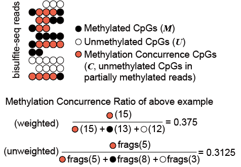

CAMDA Schematic

Not shown in the figure is the fact that CAMDA scores can be calculated for individual CpG sites (i.e. the proportion of times a CpG site is a concurrence site) or for regions of a given size (i.e. the proportion of times CpG sites in a region are concurrence sites).

The ‘size’ argument to `CAMDACalculator` sets the size of the CpG-centered region for the CAMDA score. In the original CAMDA package, this is not an option and is always set to 1 (as below).

```python
camda = CAMDACalculator(dataset, 1, min_depth=10)
iter = camda.calculate("chr1", 1245000, 1246000)
pd.DataFrame([site for site in iter])
```

|  | chrom | pos | start | end | depth | nconcurrence | camda | nconcurrence_reads | unweighted | nmeth | nunmeth | meth_pct |
| --- | --- | --- | --- | --- | --- | --- | --- | --- | --- | --- | --- | --- |
| 0 | chr1 | 1245090 | 1245090 | 1245091 | 10 | 1 | 0.100000 | 9 | 0.900000 | 9 | 1 | 0.900000 |
| 1 | chr1 | 1245105 | 1245105 | 1245106 | 13 | 3 | 0.230769 | 11 | 0.846154 | 10 | 3 | 0.769231 |
| 2 | chr1 | 1245114 | 1245114 | 1245115 | 13 | 3 | 0.230769 | 10 | 0.769231 | 10 | 3 | 0.769231 |
| 3 | chr1 | 1245123 | 1245123 | 1245124 | 14 | 0 | 0.000000 | 11 | 0.785714 | 14 | 0 | 1.000000 |
| 4 | chr1 | 1245135 | 1245135 | 1245136 | 15 | 1 | 0.066667 | 11 | 0.733333 | 14 | 1 | 0.933333 |
| 5 | chr1 | 1245146 | 1245146 | 1245147 | 19 | 1 | 0.052632 | 14 | 0.736842 | 18 | 1 | 0.947368 |
| 6 | chr1 | 1245152 | 1245152 | 1245153 | 20 | 4 | 0.200000 | 15 | 0.750000 | 16 | 4 | 0.800000 |
| 7 | chr1 | 1245159 | 1245159 | 1245160 | 22 | 5 | 0.227273 | 17 | 0.772727 | 17 | 5 | 0.772727 |
| 8 | chr1 | 1245163 | 1245163 | 1245164 | 22 | 3 | 0.136364 | 17 | 0.772727 | 19 | 3 | 0.863636 |
| 9 | chr1 | 1245167 | 1245167 | 1245168 | 24 | 2 | 0.083333 | 17 | 0.708333 | 22 | 2 | 0.916667 |
| 10 | chr1 | 1245172 | 1245172 | 1245173 | 26 | 2 | 0.076923 | 17 | 0.653846 | 24 | 2 | 0.923077 |
| 11 | chr1 | 1245175 | 1245175 | 1245176 | 27 | 4 | 0.148148 | 17 | 0.629630 | 23 | 4 | 0.851852 |
| 12 | chr1 | 1245183 | 1245183 | 1245184 | 29 | 2 | 0.068966 | 18 | 0.620690 | 27 | 2 | 0.931034 |
| 13 | chr1 | 1245219 | 1245219 | 1245220 | 32 | 4 | 0.125000 | 20 | 0.625000 | 28 | 4 | 0.875000 |
| 14 | chr1 | 1245272 | 1245272 | 1245273 | 26 | 4 | 0.153846 | 15 | 0.576923 | 22 | 4 | 0.846154 |
| 15 | chr1 | 1245322 | 1245322 | 1245323 | 20 | 1 | 0.050000 | 10 | 0.500000 | 19 | 1 | 0.950000 |
| 16 | chr1 | 1245337 | 1245337 | 1245338 | 18 | 1 | 0.055556 | 8 | 0.444444 | 17 | 1 | 0.944444 |
| 17 | chr1 | 1245373 | 1245373 | 1245374 | 12 | 0 | 0.000000 | 6 | 0.500000 | 12 | 0 | 1.000000 |
| 18 | chr1 | 1245377 | 1245377 | 1245378 | 11 | 0 | 0.000000 | 5 | 0.454545 | 11 | 0 | 1.000000 |

## Calculate concurrence scores

We can similarly calculate DNA methylation concurrence scores, i.e. in a given window, the proportion of unmethylated CpG sites in a read with at least one methylated CpG site relative to the set of all CpG sites in all reads.

**Note:** this is different from the published ‘CAMDA’ score calculated above which performs these calculations across entire reads rather than just within the window. We restrict the calculation to the window to avoid an overdependence of the calculated statistics on read length.

```python
concurrence = ConcurrenceCalculator(dataset,200)
iter = concurrence.calculate("chr1", 1245000, 1246000)
pd.DataFrame([region for region in iter])
```

|  | chrom | start | end | depth | nconcurrence | concurrence | nconcurrence_reads | unweighted | nmeth | nunmeth | meth_pct |
| --- | --- | --- | --- | --- | --- | --- | --- | --- | --- | --- | --- |
| 0 | chr1 | 1245000 | 1245200 | 32 | 47 | 0.167857 | 18 | 0.562500 | 233 | 94 | 0.712538 |
| 1 | chr1 | 1245021 | 1245220 | 32 | 46 | 0.154882 | 18 | 0.562500 | 249 | 94 | 0.725948 |
| 2 | chr1 | 1245074 | 1245273 | 36 | 45 | 0.141509 | 18 | 0.500000 | 273 | 90 | 0.752066 |
| 3 | chr1 | 1245124 | 1245323 | 36 | 33 | 0.117021 | 14 | 0.388889 | 249 | 66 | 0.790476 |
| 4 | chr1 | 1245139 | 1245338 | 36 | 33 | 0.116197 | 14 | 0.388889 | 251 | 66 | 0.791798 |
| 5 | chr1 | 1245175 | 1245374 | 37 | 16 | 0.097561 | 11 | 0.297297 | 148 | 32 | 0.822222 |
| 6 | chr1 | 1245179 | 1245378 | 36 | 12 | 0.081633 | 10 | 0.277778 | 135 | 24 | 0.849057 |
| 7 | chr1 | 1245183 | 1245382 | 36 | 13 | 0.083333 | 11 | 0.305556 | 143 | 26 | 0.846154 |
| 8 | chr1 | 1245226 | 1245425 | 21 | 5 | 0.053763 | 4 | 0.190476 | 88 | 10 | 0.897959 |

## Analysing the entire genome efficiently using multiple processors

Outputs are likely to get large and computationally more costly when generated for the entire genome rather than just a single region. Fortunately, these analyses are naturally parallalizable by chromosome using the `multiprocessing`library.

```python
import multiprocessing
concurrence = ConcurrenceCalculator(dataset,200)

def calculate_chrom_concurrences(chrom):
    iter = concurrence.calculate(chrom)
    return pd.DataFrame([region for region in iter])

chromosomes = ["chr"+str(i) for i in range(1,23)] + ["chrX"]

with multiprocessing.Pool(processes=12) as pool:
    for stats in pool.imap(calculate_chrom_concurrences, chromosomes):
        if len(stats) > 0:
            stats.to_csv("concurrences_" + stats['chrom'][0] + ".csv")
```